# Exploration of fish operation data

Alain Danet

2019-01-29

# What is known

A meeting with Camille Riviere has permit to get a lot of information about the fishing operation.

## Historic of the fishing

- Before 1995:
  - Each delegation has its own fishing protocol.
  - Favors sp with high fishing hobby interest
  - unfavorable for sp “bad” for fishing hobbies (Anguille & Lamproie)
- 1995 -: Common protocols
- 2007: Fusion of the regional “Conseil Supérieur de la Pêche” units
  - creation of ONEMA
  - Creation of the `partial_by_point` method:
    - equal to *complete* when 50 to 100 pt
- 2013 -:
  - Fishing operations are externalized
  - when complete, the passage number is know to 1!

## The fishing network

- RHP:
  - op every year
  - be careful of protocol switch
  - 2% of the site switched location
- RCS (2007-):
  - op every two years
  - standardized fishing operation

## The different fishing method

## Advise (from Camille Rivière)

- Keep *complete* if
  - series end > 2013, keep only first passage
  - length of fishing varies more than 30%, delete!
- Merge *point_big_mil* and *partial_over_be* if: *partial_over_be* op is:
  - 100% of the points on berges
  - followed over the two berges
  - the two rives have been sampled
- Exclude:
  - site near piscicole station
  - op concerning targeted species
  - if there is stocking (empoissonnement)
  - 2 following fishing operations:
    - keep the most complete
    - look at the op objective
    - can be IPR+ program

# Analysis

## Summary of the analysis

There are around 6 hundreds stations that have been followed for more than 10 times. Those stations have been sampled every year in average. The sampling methods seems homogeneous in terms of sampled area. The choice of the sampling method seems to have been decided according to the size of the river because alternative to *complete* method has been performed in the high width river. The *other* method should be exclude of the analysis because they are badly documented, not numerous and present sampled areas that 5 times higher than the other methods. For the *complete* operation, we kept only the operation which have two passages.

Following the analysis, we refined the dataset for the analysis here: `data-raw/generate_analysis_dataset.R`

## Preambule

```r
data(operation_data)
op <- dplyr::select(operation_data, opcod:year, count)
rm(operation_data)
```

There was 20809 fishing operations from 1979 to 2010. The sampling was distributed over 7174 stations. It represents a average effort of 2.9 (# visit/station).

# Sampling

## Distribution of sampling effort

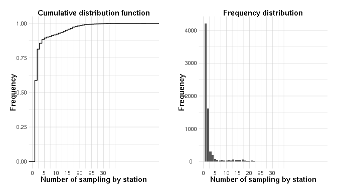

```r
op_sampling <- op %>%
  group_by(opcod, station, year, month) %>%
  summarise(
    nb_ind = sum(count),
    nb_sp  = n()
    )

op_hist <- op_sampling %>%
  group_by(station) %>%
  summarise(freq = n()) %>%
  arrange(desc(freq)) %>%
  mutate(station = fct_inorder(as.factor(station)))

cdf_op <- ggplot(op_hist, aes(x=freq)) + stat_ecdf() +
  labs(x = "Number of sampling by station",
    y = "Frequency",
    title = "Cumulative distribution function") +
  scale_x_continuous(breaks = seq(0, 30, by = 5))
hist_op <- ggplot(op_hist, aes(x = freq)) +
  geom_bar() +
  labs(x = "Number of sampling by station",
    y = "Frequency",
    title = "Frequency distribution") +
  scale_x_continuous(breaks = seq(0, 30, by = 5))

plot_grid(cdf_op, hist_op, ncol = 2)
```

Overall, the sampling effort by station is low and unevenly distributed. More than 50% of the station had been visited one time and only 10% had been visited more than 10 times. But we have no information about the spatial distribution of the station. Some of them are surely really close from each other.

## Sampling effort by year

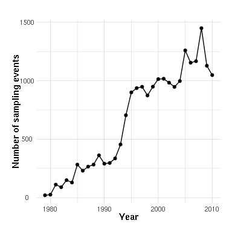

```r
op_year <- op_sampling %>% group_by(year) %>%
  summarise(freq = n()) %>%
  arrange(desc(freq))

year_op <- ggplot(op_year, aes(y = freq, x = year)) +
  geom_line() +
  geom_point() +
  labs(y = "Number of sampling events",
    x = "Year",
    title = "")
plot_grid(year_op)
```

We see that the sampling effort increase around 1992 from nearly 250 to 1000 sampled stations by year.

## Sampling area

### Where are the station best followed?

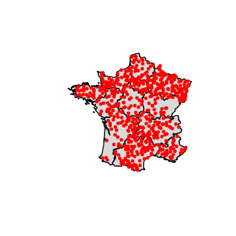

```r
# good station names
good_station <- op_hist %>%
  dplyr::filter(freq >= 10) %>%
  dplyr::select(station) %>%
  unlist(., use.names = FALSE)

# get their localisation
station <- read_delim("../data-raw/fishing_station_localisation_wsg84.csv",
  delim = ";", locale = locale("fr", decimal_mark = "."),
  col_types = cols(ST_CODECSP = col_character()))
xy_station <- dplyr::select(station, XCOORD, YCOORD)
station <- SpatialPointsDataFrame(coords = xy_station, data = station,
                               proj4string = CRS("+proj=longlat +datum=WGS84 +ellps=WGS84 +towgs84=0,0,0"))
station <- st_as_sf(station)
loc_good_station <- dplyr::filter(station, ST_ID %in% good_station)

# France map
region_fr <- raster::shapefile("../data-raw/france_region_shp/regions-20180101.shp")
##Get only metropolitan areas:
region_fr <- st_as_sf(region_fr) #easier to manipulate
region_to_filter <- c("La Réunion", "Martinique", "Guadeloupe", "Mayotte",
  "Guyane", "Corse")
region_fr <- filter(region_fr, !(nom %in% region_to_filter))
region_fr <- region_fr[, c("nom", "geometry")]

plot(st_geometry(region_fr), lwd = 1.5, col = "grey85")
plot(loc_good_station, pch = 20, col = "red", add = T)
```

#### Number of individuals and species by sampling operation

```r
good_station_sampling <- op_sampling %>%
  dplyr::filter(station %in% good_station)
filter(good_station_sampling, nb_sp ==0)
```

```
#> # A tibble: 0 x 6
#> # Groups:   opcod, station, year [0]
#> # … with 6 variables: opcod <int>, station <int>, year <int>, month <int>,
#> #   nb_ind <int>, nb_sp <int>
```

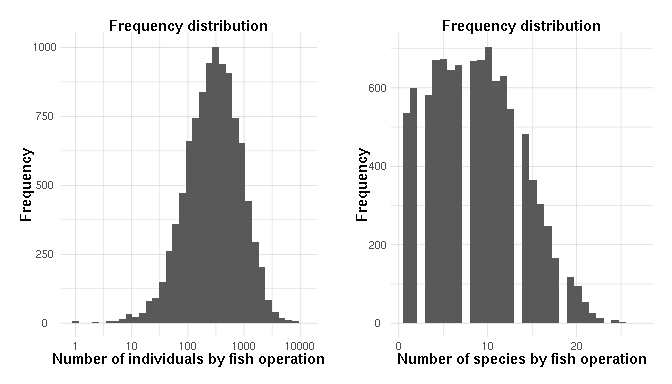

```r
hist_good_station <- good_station_sampling %>%
  ungroup() %>%
  mutate(station = fct_inorder(as.factor(station)))

hist_ind <- ggplot(hist_good_station, aes(x = nb_ind)) +
  geom_histogram(bins = 35) +
  labs(x = "Number of individuals by fish operation",
    y = "Frequency",
    title = "Frequency distribution") +
  scale_x_log10()
hist_sp <- ggplot(hist_good_station, aes(x = nb_sp)) +
  geom_histogram(bins = 32) +
  labs(x = "Number of species by fish operation",
    y = "Frequency",
    title = "Frequency distribution")
plot_grid(hist_ind, hist_sp, ncol = 2)
```

#### Regularity of monitoring

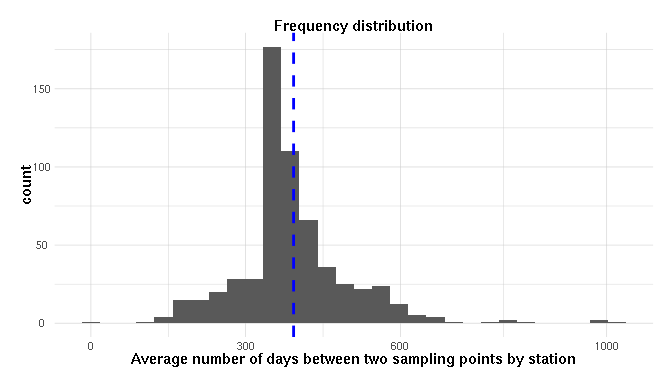

```r
time_sampling <- good_station_sampling %>%
  ungroup() %>%
  unite(year_month, year, month, sep = "-") %>%
  mutate(times = ymd(paste0(year_month, "-01"))) %>%
  dplyr::select(-year_month)

time_sampling %<>%
  group_by(station) %>%
  arrange(times) %>%
  mutate(
    point = seq(1, length(station)),
    sample_sep = c(NA, times[-1] - times[-length(station)])
  )
hist_time_int <- time_sampling %>%
  summarise(mean_sep = mean(sample_sep, na.rm =TRUE))

global_sep <- ggplot(time_sampling, aes(x = sample_sep)) +
  geom_histogram() +
  geom_vline(aes(xintercept=mean(sample_sep, na.rm = TRUE)),
            color="blue", linetype="dashed", size=1) +
  labs(title = "Frequency distribution",
  x = "Number of days between two sampling points") +
scale_x_continuous(breaks = c(0, 300, 600, 1000, 2000))

average_sep <- ggplot(hist_time_int, aes(x = mean_sep)) +
  geom_histogram() +
  geom_vline(aes(xintercept = mean(mean_sep)),
            color="blue", linetype="dashed", size=1) +
  labs(title = "Frequency distribution",
  x = "Average number of days between two sampling points by station") +
scale_x_continuous(breaks = c(0, 300, 600, 1000, 2000))

plot_grid(average_sep, ncol = 1)
```

The fishing operations (FO) resulted in the collect of several hundreds of fish (492.961901 fishes in average) which is quite impressive. The delay between two fishing operations by station was of 393 days, iow 1 year which is great! However, the FO that have been spaced by less than one month (30 days), have been taken place the same day! It is normal because I do not have a date resolution thiner than the month!

```r
# Get operation data
data(operation_data)
operation_data %<>% distinct(opcod, .keep_all = TRUE) %>%
  dplyr::select(-species, -station, -count, -year, -month)
st_method <- left_join(good_station_sampling, operation_data, by = c("opcod")) %>%
  ungroup()
```

```r
low_fo_int <- filter(time_sampling, sample_sep < 30) %>%
  ungroup() %>%
  arrange(station) %>%
  left_join(., operation_data, by = c("opcod"))
# Those FO took place the same day:
summarise(low_fo_int, mean = mean(sample_sep))
```

```
#> # A tibble: 1 x 1
#>    mean
#>   <dbl>
#> 1     0
```

```r
# Sometimes the first FO was not successful:
filter(time_sampling, station ==  140, point %in% c(9, 10))
```

```
#> # A tibble: 2 x 7
#> # Groups:   station [1]
#>   opcod station nb_ind nb_sp times      point sample_sep
#>   <int>   <int>  <int> <int> <date>     <int>      <dbl>
#> 1  1659     140      4     1 2006-09-01     9        365
#> 2  1696     140   1481     5 2006-09-01    10          0
```

```r
filter(time_sampling, station ==  472, point %in% c(6, 7))
```

```
#> # A tibble: 2 x 7
#> # Groups:   station [1]
#>   opcod station nb_ind nb_sp times      point sample_sep
#>   <int>   <int>  <int> <int> <date>     <int>      <dbl>
#> 1   878     472     25     2 1991-10-01     6        153
#> 2   883     472    152     6 1991-10-01     7          0
```

```r
# But sometimes, no:
filter(time_sampling, station ==  186, point %in% c(4, 5))
```

```
#> # A tibble: 2 x 7
#> # Groups:   station [1]
#>   opcod station nb_ind nb_sp times      point sample_sep
#>   <int>   <int>  <int> <int> <date>     <int>      <dbl>
#> 1   270     186    385    14 1997-07-01     4        395
#> 2   271     186    302    15 1997-07-01     5          0
```

```r
filter(time_sampling, station ==  244, point %in% c(15, 16))
```

```
#> # A tibble: 2 x 7
#> # Groups:   station [1]
#>   opcod station nb_ind nb_sp times      point sample_sep
#>   <int>   <int>  <int> <int> <date>     <int>      <dbl>
#> 1  1474     244    269    17 2004-06-01    15        366
#> 2  1875     244    554    13 2004-06-01    16          0
```

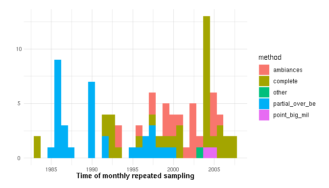

```r
# Is it because of differences of sampling methods?

#
qplot(times, data = low_fo_int, fill = method) +
  labs(x = "Time of monthly repeated sampling")
```

```r
#To generalize...
```

It concerns 96 stations, 16% of the good stations.

#### Sampling method regularity

We want to see if the good stations had the same sampling methods across time.

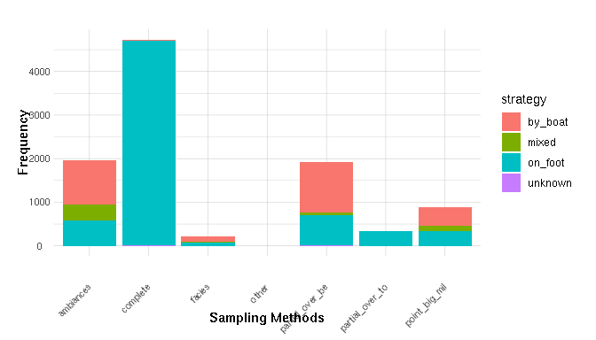

```r
## Global distribution of the methods and fishing strategies:
p_met <- ggplot(st_method, aes(method, fill = strategy)) +
  geom_bar() +
  labs(x = "Sampling Methods",
    y = "Frequency",
    title = "") +
  theme(axis.text.x = element_text(angle = 45, hjust = 1))
p_met
```

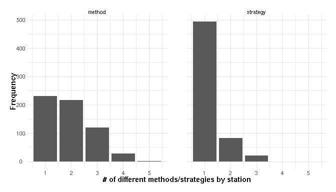

```r
## Distribution of sampling methods/strategies by station
distri_samp <- st_method %>%
  group_by(station) %>%
  summarise(
    method = length(unique(method)),
    strategy = length(unique(strategy))
  )
p_samp <- ggplot(gather(distri_samp, samp, uniq, method, strategy), aes(x = uniq)) +
  geom_bar() +
  labs(x = "# of different methods/strategies by station",
  y = "Frequency") +
  facet_grid(cols = vars(samp))
p_samp
```

Most of the FO has been realized with the “on foot” strategy. It is probable that boat has been used in case which the river was too deep. It is more complicated for the methods. We see hopefully that the methods the most frequently used was “complete”. However, when looking at the number of different methods used for each station, we see that in general, 1 to 3 methods are used inside a station.

When there are 2 sampling events at the same station, do they belong to methods different from complete ? If so, can we merge them ? If not, are they separated by less than one year ? If not, we should delete them I guess.

#### Characteristics of the sampling methods

```r
# let see the states of the variables
op_type <- read_csv("../data-raw/fish_op_variables.csv")
knitr::kable(op_type)
```

| variable | modalite | sens |
| --- | --- | --- |
| station | NA | portion de cours d’eau qui a fait l’objet de l’échantillonnage |
| method | on_foot | pêche à pied |
| method | on_boat | pêche en bateau |
| method | mix | pêche mixte à pied et en bateau, lorsque la variabilité locale de la profondeur empêche la mise en œuvre du même moyen de prospection sur toute la superficie à pêcher |
| strategy | complete | pêche complète de la totalité de la station |
| strategy | part_ambiance | pêche partielle par ambiance de la totalité de la station |
| strategy | part_point | point grand milieux |
| strategy | part_berg | pêche partielle d’une certaine distance de berge pouvant être répétée |
| strategy | other | autre méthode de pêche partielle |
| surf | km | surface réellement prospectée. Pour une pêche complète il s’agit de la largeur en eau multipliée par la longueur pêchée ; pour les pêches partielles, il s’agit de la somme des surfaces des sous-unités… |
| nb_pass | int | nombre de passages réalisés dans le cas d’une pêche complète |
| NBZON | int | nombre de sous-unités d’échantillonnages (ambiance, faciès, placettes…) lors d’une pêche partielle |
| NBSYST | int | nombre de points systématiques dans le cas d’une pêche par point grands milieux |
| NBCOMPL | int | ombre de points complémentaires dans le cas d’une pêche par point grands milieux |

- What matters the most:
  - sampling permit to have a good idea of community composition
    - adequat sampling
    - adequat sampling effort

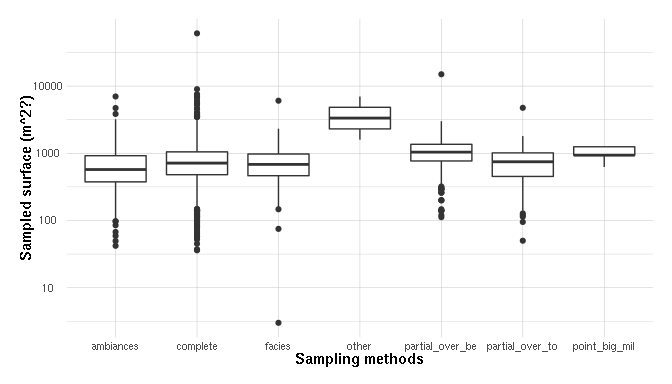

```r
p_surf <- ggplot(st_method, aes(x = method, y = surf)) +
  geom_boxplot() +
  scale_y_log10() +
  labs(x = "Sampling methods", y = "Sampled surface (m^2?)")
p_surf
```

The sampled surfaces are in the same order, which is good. It remains the question to know if each sampling method allow to have a unbiaised estimation of the abundances of the species.

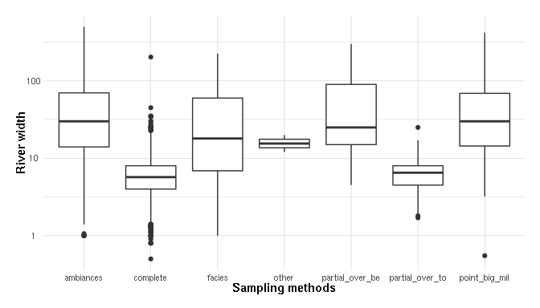

```r
data(environmental_data)
st_env <- left_join(st_method, environmental_data, by = "opcod")

# Let's see if some sampling point were to large to perform complete:
width_meth <- ggplot(st_env, aes(x = method, y = width)) +
  geom_boxplot() +
  scale_y_log10() +
  labs(x = "Sampling methods", y = "River width")
width_meth
```

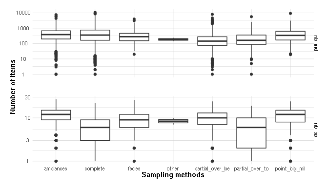

```r
# Let see the correlation between methods and the output of the fishing
# operation
fo_out_methods <- ggplot(gather(st_env, var, nb, nb_ind, nb_sp), aes(x = method, y = nb)) +
  geom_boxplot() +
  scale_y_log10() +
  facet_grid(rows = vars(var), scale = "free_y") +
  labs(x = "Sampling methods", y = "Number of items")
fo_out_methods
```

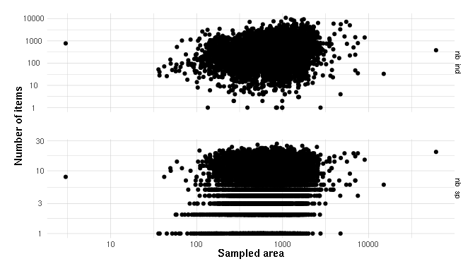

```r
## Can those variation be explained by the  area ?
fo_out_surf<- ggplot(gather(st_env, var, nb, nb_ind, nb_sp), aes(x = surf, y = nb)) +
  geom_point() +
  scale_y_log10() +
  scale_x_log10() +
  facet_grid(rows = vars(var), scale = "free_y") +
  labs(x = "Sampled area", y = "Number of items")
fo_out_surf
```

They are quite some differences in the number of species and individuals sampled according to different methods. But those differences could be attributed to differences in sampled areas.

#### Quantification of the sampling effort

There is several ways to quantify the sampling effort: - Sampled area over the river width

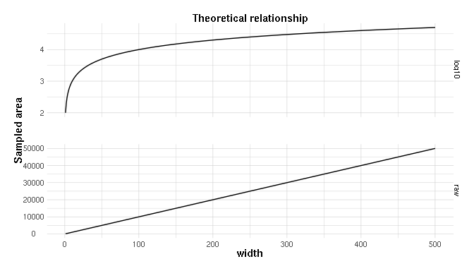

```r
cte <- 100
test <- tibble(
  width = seq(1, 500),
  raw = width * cte,
  log10 = log10(raw)
)
test %<>% gather(method, surf, raw, log10)
th_surf_width <- ggplot(test, aes(y = surf, x = width)) +
  geom_line() +
  #scale_x_log10() +
  facet_grid(vars(method), scales = "free_y") +
  labs(y = "Sampled area", y = "River width",
    title = "Theoretical relationship")
th_surf_width
```

If we assume a constant length of transect (but it does not make a lot of sens for other than *complete*), we expect a linear relationship between the sampled surface and the width of the river. At the log scale, we then expect a saturating relationship.

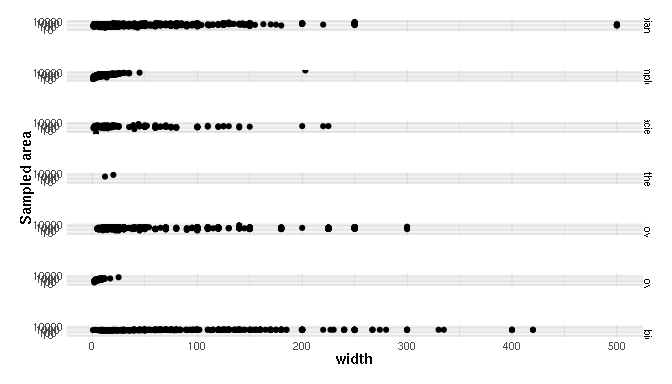

```r
surf_width <- ggplot(st_method, aes(y = surf, x = width)) +
  geom_point() +
  scale_y_log10() +
  #scale_x_log10() +
  facet_grid(vars(method)) +
  labs(y = "Sampled area", y = "River width")
surf_width
```

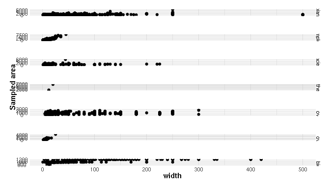

```r
# Let's try again without the two big sampled areas
# and free scale for each panel
surf_width <- ggplot(filter(st_method, surf < 10000), aes(y = surf, x = width)) +
  geom_point() +
  facet_grid(vars(method), scales = "free_y") +
  labs(y = "Sampled area", y = "River width")
surf_width
```

We see know that only the *complete* and *partial_over_to* displayed a linear relationship between sampled surface and river width. It means that the other methods displayed a more or less constant relationship (*partial_over_be* and *ambiances* and *facies*).

I think about two solutions: - We rarefy the little river to equal the poor sampling effort of the big river. - We separate big rivers and little rivers in the analysis.

What is important is that the sampling effort is homogeneous within station, right ?

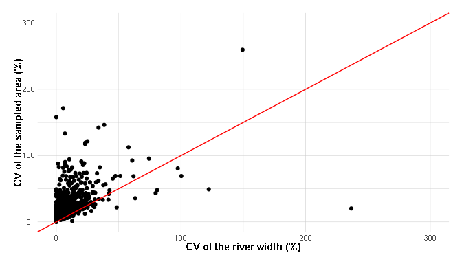

```r
# Let's compute the coefficient of variation of sampled area for each station
cv_st <- st_method %>%
  group_by(station) %>%
  summarise(
    avg_width = mean(width, na.rm = TRUE),
    sd_width = sd(width, na.rm = TRUE),
    avg_surf = mean(surf, na.rm = TRUE),
    sd_surf = sd(surf, na.rm = TRUE)
  )

p_cv_surf_width <- ggplot(cv_st, aes(y = sd_surf / avg_surf * 100, x = sd_width / avg_width * 100)) +
  geom_point() +
  geom_abline(intercept = 0, slope = 1, color = "red") +
  ylim(0, 300) + xlim(0, 300) +
  labs(y = "CV of the sampled area (%)", x = "CV of the river width (%)")
p_cv_surf_width
```

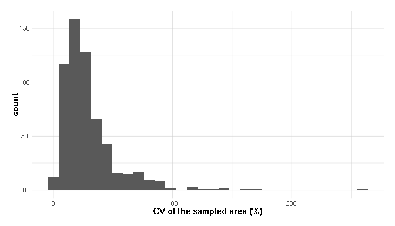

```r
p_cv_surf <- ggplot(cv_st, aes(x = sd_surf / avg_surf * 100)) +
  geom_histogram() +
  labs(x = "CV of the sampled area (%)")
p_cv_surf
```

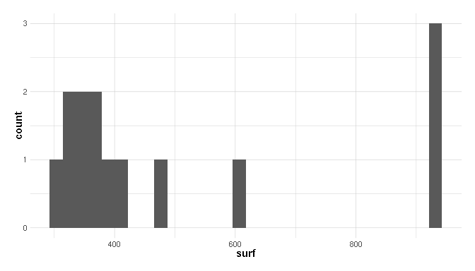

```r
## Watch one
st_test <- filter(st_method, station == sample(good_station, 1))
ggplot(st_test, aes(x = surf)) +
  geom_histogram()
```

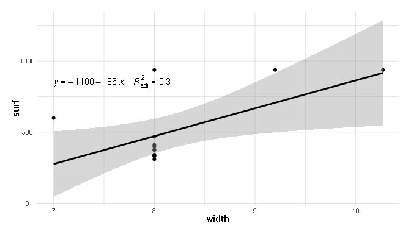

```r
formul <- y ~ x
ggplot(st_test, aes(y = surf, x = width)) +
  geom_point() +
  geom_smooth(method = "lm", color="black") +
  stat_poly_eq(aes(label =  paste(..eq.label.., ..adj.rr.label.., sep = "~~~~")),
               formula = formul, parse = TRUE)
```

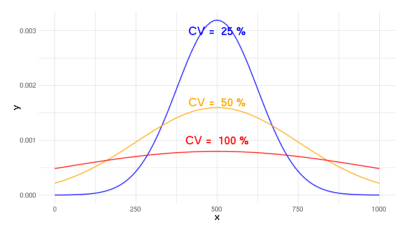

```r
## Theoretical CV
gen_curve <- function (avg, cv, color) {
  stat_function(fun = dnorm, args = list(mean = avg, sd = cv * avg),
    color = color)
}
gen_label <- function (cv, color, ylabel, avg) {
  annotate("text", x = avg, y = ylabel, label = paste("CV = ", cv * 100, "%"), color = color, size = 5)
}
### data_curve
test <- tibble(
  avg = 500,
  cv = c(.25, .5, 1),
  color = c("blue", "orange", "red"),
  ylabel = c(1.5, .85, .5) / avg
)
### Generate curve
test <- mutate(test, curves = pmap(list(avg, cv, color), gen_curve))
### Generate labels
test <- mutate(test, label = pmap(list(cv, color, ylabel, avg), gen_label))
## Plot
th_cv <- ggplot(data.frame(x = c(0, 1000)), aes(x)) +
  test$curves +# list of curve
  test$label
th_cv
```

The theoretical curve shows that, in case of normal distribution, it would be safe to remove station were the CV is superior to $.25$. However, this measure does not take in account the shift of river width. Further exploration are needed.

One idea: if the length of the transect is *constant*. For each station, we compute the residuals of the relation between sampled area and the width of the river

# Check variables

```
#> Warning: Removed 5246 rows containing non-finite values (stat_bin).
```

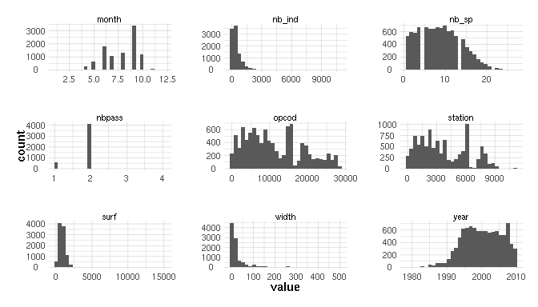

```r
st_method %>%
  keep(is.numeric) %>%
  filter(surf < 20000) %>%
  gather() %>%
  ggplot(aes(value)) +
    facet_wrap(~ key, scales = "free") +
    geom_histogram()
```

```r
# It seems that some sampled surfaces are really big:
filter(st_method, surf > 5000)
filter(st_method, station == 8609)
filter(st_method, station == 2952)
## It seems that it is some keyboard errors

# It seems that some sampled surfaces are really big:
filter(st_method, width > 300)
st_method %<>% ungroup()
filter(st_method, method != "complete") %>%
  dplyr::select(nbpass) %>%
  unique()
```